# Predictive Modelling (SAS)

Author

Sean Vieau

Published

December 24, 2024

# Introduction

The aim of the current study is to investigate whether MRI image features extracted from baseline kidney images can enhance the prediction of disease progression in young Autosomal Dominant Polycystic Kidney Disease (ADPKD) patients. This study is important because recent literature has demonstrated the inclusion of MRI image features improves the prognostic accuracy of models in adults, but this has not yet been demonstrated in children. Improving prediction models could greatly assist in diagnosing and predicting kidney disease outcomes in children, which is more challenging than in adults and could lead to improved treatment.

Note: There is a lot of extraneous work I did when I originally performed this in R when exploring the data set, and we will not be retreading that in this SAS analysis.

[figure not shown]

#### Task One

[figure not shown]

#### Task Two

[figure not shown]

### Clinical Hypotheses

The two clinical hypotheses for this study are that including MRI image features will improve model performance compared to using baseline kidney volume alone in models predicting

1. Percentage change of total kidney volume growth
2. Classification of a patient as having fast or slow progression of the disease.

# Background

Here we will review background information on the methodology and variables provided in this data set.

## Gabor Transform

#### What is it

The Gabor Transform, named after Dennis Gabor, is a powerful technique for analyzing the **texture** of MRI images. By convolving the image with a Gabor filter, it becomes possible to discriminate between features based on intensity differences. This allows the target region and background to be differentiated if they possess distinct features, as they will exhibit different intensity levels. Moreover, the Gabor Transform has tunable parameters, such as the frequency of the sinusoidal wave, which can be adjusted to extract specific textures from the images. Higher frequencies are ideal for capturing fine textures, while lower frequencies are better suited for coarse textures.

#### How it Works

The Gabor Filter first applies a Gaussian Envelope to focus on a small region of the image. It then applies a sinusoidal wave that oscillates at a specific frequency and captures the variation in intensities at that frequency and orientation within that region.

#### Example of Gabor Transform

[figure not shown]

Example of applying a Gaussian, then Gabor, and Laplacian Filter (GGL) for differentiation between two different textures (+’s vs L’s) ([2](https://link.springer.com/article/10.1007/BF00204594)).

#### Image Features Provided by the Gabor Transform

In general, Gabor functions can easily extract features of:

- Spatial Frequency (e.g. how often pixel intensity changes in a given area)
- Density (e.g. concentration of features within a certain area)
- Orientation (e.g. Textures or edges at 0°, 45°, 90°, 135°)
- Phase (e.g. alignment/distance of features)
- Energy (e.g. overall intensity)

Sources: [1](https://link.springer.com/article/10.1007/s11042-020-09635-6), [2](https://link.springer.com/article/10.1007/BF00204594)

## Gray Level Co-Occurrence Matrix

#### What is it

The Gray Level Co-Occurrence Matrix (GLCM) is another powerful tool for extracting **texture** features from an MRI image. GLCM works under the assumption that the textural information in an image is contained in the “average” spatial relationship that the gray tones in the image have to each other. For example, when a small patch of the picture has little variation of features, the dominant property is tone; When a small patch of a picture has high variation, the dominant property is texture ([3](https://ieeexplore.ieee.org/document/4309314)).

#### How it Works

GLCM examines the spatial relationship between pairs of pixels in an image and calculates how often pairs of pixel values occur at a specified distance and orientation. It does this by computing a set of gray-tone spacial-dependence matrices for various angular relationships and distances between neighboring resolution cell pairs on the image ([3](https://ieeexplore.ieee.org/document/4309314)).

#### Example of GLCM

[figure not shown]

Example of textural features extracted from two different land-use category images ([3](https://ieeexplore.ieee.org/document/4309314)).

#### Image Features Provided by GLCM

In general, GLCM provides information on the following features:

- Homogeneity
- Linear Structure
- Contrast
- Number and Nature of Boundaries
- Complexity of the Image

## Local Binary Pattern

#### What is it

The Local Binary Pattern (LBP) is a third powerful method for extracting **texture** features from an image. An important and fundamental property of texture is how uniform the patterns are, and LBP captures this by detecting these uniform patterns in circular neighborhoods at any rotation and spatial resolution. LBP is rotation invariant, meaning it does not matter what rotation the image is at; it will always extract very similar features) ([4](https://ieeexplore.ieee.org/document/1017623)).

#### How it Works

LBP works by comparing the intensity of a central pixel with its neighboring pixels and encoding this relationship into a binary pattern. For each neighbor, if it’s intensity is greater or equal to the central pixel, it gets assigned a 1 (otherwise a 0). The binary values of all neighbors are then concatenated to form a binary number, and this number is converted into a decimal that represent the LBP for the central pixel ([4](https://ieeexplore.ieee.org/document/1017623)).

#### Example of LBP

[figure not shown]

Example of the 36 unique comparisons that can be made between neighboring pixels ([4](https://ieeexplore.ieee.org/document/1017623)).

#### Code Information

[figure not shown]

#### Image Features Provided by the LBP

In general, the LBP provides image features on:

- Uniformity
- Local Contrast
- Texture Description
- Spatial Patterns
- Gray Level Distribution

# Method

## Study Design

The investigators recruited 71 young patients with ADPKD and collected MRI data at baseline and after 3 years. Additionally, the height corrected kidney volume for each patient was collected at baseline and 3 years by a physician, and the percentage change calculated. Patients were classified as having slow or fast progression of the disease based on this percentage change. Image features were extracted from the baseline MRI images including 2 image features on kidney geometric information, 5 features based on Gabor transform, 2 features based on gray level co-occurrence matrix, 5 features based on image textures, and 5 features based on local binary pattern.

### Statistical Hypotheses

1. A **linear regression model** predicting **percentage change of total kidney volume growth** including MRI image features and baseline kidney volume will have better performance than a model with baseline kidney volume alone, as determined by specificity, sensitivity, PPV, NPV, accuracy, and AUC.
2. A **logistic regression model** predicting **classification of disease progression as slow or fast** including MRI image features and baseline kidney volume will have better performance than a model with baseline kidney volume alone, as determined by specificity, sensitivity, PPV, NPV, accuracy, and AUC.

# Data Preparation

## Connect to SAS

```r
# This code connects to SAS On Demand
library(configSAS)
configSAS::set_sas_engine()
```

```
Using SAS Config named: oda
SAS Connection established. Subprocess id is 4788
```

````r
#  This code allows you to run ```{sas}``` chunks
sas = knitr::opts_chunk$get("sas")
````

## Create Library

```sas
* Create library;
%LET CourseRoot = /home/u63376223/sasuser.v94/Advanced Data Analysis;
LIBNAME Proj3 "&CourseRoot/Project 3 Predictive Model";
```

## Read In Data

```sas
* Import the dataset;
PROC IMPORT
    DATAFILE = "&CourseRoot/Project 3 Predictive Model/Project3_data.csv"
    OUT = Proj3.data
    REPLACE;
    GETNAMES = YES;
    RUN;
```

## Examine Data

```sas
* Examine data;
PROC PRINT DATA = PROJ3.Data (OBS=6);
    RUN;
```

**lst**

The SAS System

| Obs | Subject ID | geom1 | geom2 | gabor1 | gabor2 | gabor3 | gabor4 | gabor5 | glcm1 | glcm2 | txti1 | txti2 | txti3 | txti4 | txti5 | lbp1 | lbp2 | lbp3 | lbp4 | lbp5 | tkvht_base | tkvht_visit2 | progression | tkvht_change |
| --- | --- | --- | --- | --- | --- | --- | --- | --- | --- | --- | --- | --- | --- | --- | --- | --- | --- | --- | --- | --- | --- | --- | --- | --- |
| 1 | 1 | 1.071922859 | 1.149018615 | -0.029205293 | -0.079807149 | 0.002330791 | 0.000852949 | 0.006369181 | 405.5714233 | 164488.1794 | -4.401442194 | -12.08514995 | 53.19208893 | 19.37269339 | 146.0508494 | -0.521181744 | 0.081225947 | -0.042333481 | 0.27163041 | 0.006597654 | 435 | 585 | 1 | 11.44 |
| 2 | 2 | 54.03147612 | 2919.400411 | -0.049985252 | -0.126631032 | 0.006329684 | 0.002498525 | 0.016035418 | -580.9386534 | 337489.7191 | 3.595325019 | -1.991768234 | -7.161054166 | 12.926362 | 3.967140699 | -0.55724044 | -0.466561063 | 0.259986692 | 0.310516908 | 0.217679225 | 555 | 595 | 0 | 2.42 |
| 3 | 3 | -32.02438892 | 1025.561486 | -0.015271484 | 0.0424398 | -0.000648119 | 0.000233218 | 0.001801137 | -1037.25839 | 1075904.968 | 25.36733564 | -5.308749186 | -134.6688224 | 643.5017174 | 28.18281792 | -0.251547115 | 0.677893451 | -0.170522142 | 0.063275951 | 0.459539531 | 191 | 249 | 1 | 10.08 |
| 4 | 4 | -42.8324855 | 1834.621814 | -0.015394838 | 0.043545875 | -0.000670382 | 0.000237001 | 0.001896243 | -1018.078916 | 1036484.679 | 25.51853114 | -5.561043005 | -141.9096491 | 651.1954318 | 30.9251993 | -0.246369599 | 0.66845853 | -0.16468786 | 0.060697979 | 0.446836807 | 334 | 498 | 1 | 16.47 |
| 5 | 5 | -10.63734442 | 113.1530962 | 0.163043661 | 0.079753327 | 0.013003274 | 0.026583235 | 0.006360593 | 64.64082706 | 4178.436523 | 2.446874615 | -6.297954169 | -15.41030418 | 5.98719538 | 39.66422672 | -0.566313835 | 0.267699416 | -0.151601883 | 0.32071136 | 0.071662977 | 263 | 311 | 0 | 6.14 |
| 6 | 6 | 71.07947699 | 5052.292049 | -0.082449171 | -0.110154232 | 0.009082125 | 0.006797866 | 0.012133955 | -1459.904295 | 2131320.55 | 2.432427468 | -6.506258344 | -15.82600151 | 5.916703385 | 42.33139764 | -1.199913635 | -0.110897204 | 0.133067067 | 1.439792732 | 0.01229819 | 609 | 793 | 1 | 10.09 |

**log**

[output not shown]

## Examine Formats

```sas
* Examine formats;
PROC CONTENTS DATA = PROJ3.DATA;
    RUN;
```

**lst**

The SAS System

The CONTENTS Procedure

| Data Set Name | PROJ3.DATA | Observations | 71 |
| --- | --- | --- | --- |
| Member Type | DATA | Variables | 24 |
| Engine | V9 | Indexes | 0 |
| Created | 12/19/2025 03:53:40 | Observation Length | 192 |
| Last Modified | 12/19/2025 03:53:40 | Deleted Observations | 0 |
| Protection |  | Compressed | NO |
| Data Set Type |  | Sorted | NO |
| Label |  |  |  |
| Data Representation | SOLARIS_X86_64, LINUX_X86_64, ALPHA_TRU64, LINUX_IA64 |  |  |
| Encoding | utf-8 Unicode (UTF-8) |  |  |

| Engine/Host Dependent Information |  |
| --- | --- |
| Data Set Page Size | 131072 |
| Number of Data Set Pages | 1 |
| First Data Page | 1 |
| Max Obs per Page | 682 |
| Obs in First Data Page | 71 |
| Number of Data Set Repairs | 0 |
| Filename | /home/u63376223/sasuser.v94/Advanced Data Analysis/Project 3 Predictive Model/data.sas7bdat |
| Release Created | 9.0401M8 |
| Host Created | Linux |
| Inode Number | 19396024701 |
| Access Permission | rw-r–r– |
| Owner Name | u63376223 |
| File Size | 256KB |
| File Size (bytes) | 262144 |

| Alphabetic List of Variables and Attributes # | Alphabetic List of Variables and Attributes Variable | Alphabetic List of Variables and Attributes Type | Alphabetic List of Variables and Attributes Len | Alphabetic List of Variables and Attributes Format | Alphabetic List of Variables and Attributes Informat |
| --- | --- | --- | --- | --- | --- |
| 1 | Subject ID | Num | 8 | BEST12. | BEST32. |
| 4 | gabor1 | Num | 8 | BEST12. | BEST32. |
| 5 | gabor2 | Num | 8 | BEST12. | BEST32. |
| 6 | gabor3 | Num | 8 | BEST12. | BEST32. |
| 7 | gabor4 | Num | 8 | BEST12. | BEST32. |
| 8 | gabor5 | Num | 8 | BEST12. | BEST32. |
| 2 | geom1 | Num | 8 | BEST12. | BEST32. |
| 3 | geom2 | Num | 8 | BEST12. | BEST32. |
| 9 | glcm1 | Num | 8 | BEST12. | BEST32. |
| 10 | glcm2 | Num | 8 | BEST12. | BEST32. |
| 16 | lbp1 | Num | 8 | BEST12. | BEST32. |
| 17 | lbp2 | Num | 8 | BEST12. | BEST32. |
| 18 | lbp3 | Num | 8 | BEST12. | BEST32. |
| 19 | lbp4 | Num | 8 | BEST12. | BEST32. |
| 20 | lbp5 | Num | 8 | BEST12. | BEST32. |
| 23 | progression | Num | 8 | BEST12. | BEST32. |
| 21 | tkvht_base | Num | 8 | BEST12. | BEST32. |
| 24 | tkvht_change | Num | 8 | BEST12. | BEST32. |
| 22 | tkvht_visit2 | Num | 8 | BEST12. | BEST32. |
| 11 | txti1 | Num | 8 | BEST12. | BEST32. |
| 12 | txti2 | Num | 8 | BEST12. | BEST32. |
| 13 | txti3 | Num | 8 | BEST12. | BEST32. |
| 14 | txti4 | Num | 8 | BEST12. | BEST32. |
| 15 | txti5 | Num | 8 | BEST12. | BEST32. |

**log**

[output not shown]

The data is completely clean and everything is numeric as it should be! We also have no missing variables in this data set.

## Create Factors

Let’s just convert `progression` into a factor that contains the levels for “slow” or “fast’ and we’re good to go.

```sas
* Create format;
PROC FORMAT;
    VALUE ProgressionCd
        0 = "Slow"
        1 = "Fast";
    RUN;

* Apply Format;
DATA Proj3.Data;
    SET Proj3.Data;
    FORMAT progression ProgressionCd.;
    RUN;
```

#### Summary

Our data set consists of:

- 71 patients
- 19 MRI image features
- 4 kidney volume variables

# Data Split

#### Background

We have an N of 71, which is notably small.

[figure not shown]

# Feature Engineering I

## Correlation Matrix I

To assess for the best engineering of features and select the most promising covariates for this predictive model, I will create the following correlation matrices.

- With unaltered features & engineered features
- With averages and interactions to aggregate features from the same class
- With squared features

This process should uncover hidden relationships between features that are not immediately obvious (such as a squared feature being a significant predictor, but not in its original form).

This first matrix will contain the unaltered features in their original form, as well as the engineered features as determined by examination of distributions.

#### Create Correlation Matrix

```sas
* Print correlation matrix;
PROC CORR DATA = Proj3.Data OUTP = corr_matr;
    VAR tkvht_base tkvht_change progression  geom1 geom2 gabor1 gabor2  gabor3  gabor4  gabor5  glcm1   glcm2   txti1   txti2   txti3   txti4   txti5   lbp1    lbp2    lbp3    lbp4    lbp5; * List variables here;
    RUN;

* Create a dataset with only the correlation coefficients;
DATA corr_only;
    SET corr_matr;
    IF _TYPE_ = 'CORR'; /* Select only the rows with correlation coefficients */
RUN;

* Reshape the correlation matrix for the heat map;
DATA heatmap_data;
    SET corr_only;
    ARRAY vars[*] tkvht_base tkvht_change  progression  geom1 geom2 gabor1  gabor2  gabor3  gabor4  gabor5  glcm1   glcm2   txti1   txti2   txti3   txti4   txti5   lbp1    lbp2    lbp3    lbp4    lbp5; * List variables here;
    DO i = 1 to DIM(vars);
        ROW = _NAME_;
        COL = VNAME(vars[i]);
        corr_value = vars[i];
        IF NOT missing(corr_value) THEN DO;
            LABEL = PUT(corr_value, 8.2); * Format the text label;
            OUTPUT;
        END;
    END;
    KEEP row col corr_value label;
RUN;
```

#### Plot the Correlation Matrix as a Heat Map

```sas
* Set the dimensions of the output graphic;
ODS GRAPHICS / WIDTH=1000px HEIGHT=800px;

* Create the Heat Map;
PROC SGPLOT DATA=heatmap_data;
    HEATMAPPARM X=col Y=row COLORRESPONSE = corr_value / COLORMODEL = (blue white red);
    TEXT X=col Y=row TEXT=label / TEXTATTRS = (SIZE=8) POSITION = center;
    XAXIS DISPLAY = (nolabel) DISCRETEORDER = data;
    YAXIS DISPLAY=(nolabel) DISCRETEORDER = data;
    TITLE "Correlation Matrix Heat Map";
RUN;
```

**lst**

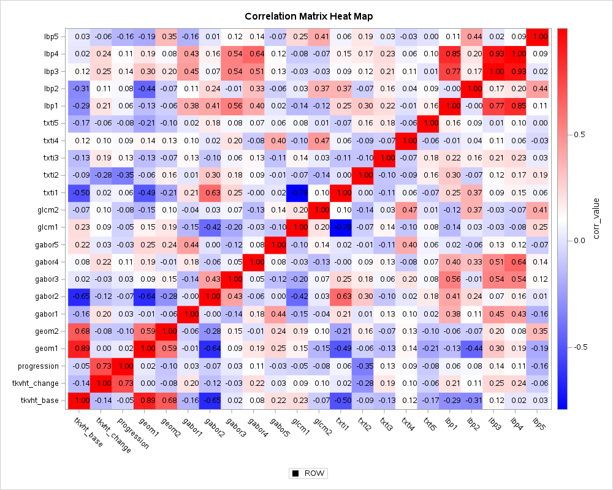

**log**

[output not shown]

## Summary

The variables with the strongest correlations to `tkvht_change` are:

- `gabor1` (r = 0.20)
- `gabor4` (r = 0.22)
- `txti2` (r = 0.28)
- `txti3` (r= 0.19)
- `lbp1` (r = 0.21)
- `lbp3` (r = 0.25)
- `lbp4` (r = 0.24)

# Feature Engineering II

We had several variables of the same class (e.g. from the local binding pattern) that were correlated with the change in kidney volume size.

In the interest of discovering underlying patterns, I will attempt to collapse these variables by

- Taking their average
- Taking their interaction term

#### Create Averages and Interaction Terms

```sas
** Create Average and Interaction Terms;
DATA Proj3.Data;
    SET Proj3.Data;
    gabor_avg = mean(gabor1 + gabor4);
    gabor_int = gabor1*gabor4;
    txti_avg = mean(txti2 + txti3);
    txti_int = txti2*txti3;
    lbp_avg = mean(lbp1 + lbp3 + lbp4);
    lbp_int = lbp1*lbp3*lbp4;
    RUN;
```

## Correlation Matrix II

#### Create Correlation Matrix

```sas
* Print correlation matrix;
PROC CORR DATA = Proj3.Data OUTP = corr_matr;
    VAR tkvht_base tkvht_change progression gabor_avg gabor_int txti_avg txti_int lbp_avg lbp_int;
    RUN;

* Create a dataset with only the correlation coefficients;
DATA corr_only;
    SET corr_matr;
    IF _TYPE_ = 'CORR'; /* Select only the rows with correlation coefficients */
RUN;

* Reshape the correlation matrix for the heat map;
DATA heatmap_data;
    SET corr_only;
    ARRAY vars[*] tkvht_base tkvht_change progression gabor_avg gabor_int txti_avg txti_int lbp_avg lbp_int;
    DO i = 1 to DIM(vars);
        ROW = _NAME_;
        COL = VNAME(vars[i]);
        corr_value = vars[i];
        IF NOT missing(corr_value) THEN DO;
            LABEL = PUT(corr_value, 8.2); * Format the text label;
            OUTPUT;
        END;
    END;
    KEEP row col corr_value label;
RUN;
```

#### Plot the Correlation Matrix as a Heatmap

```sas
* Set the dimensions of the output graphic;
ODS GRAPHICS / WIDTH=1000px HEIGHT=800px;

* Create the Heat Map;
PROC SGPLOT DATA=heatmap_data;
    HEATMAPPARM X=col Y=row COLORRESPONSE = corr_value / COLORMODEL = (blue white red);
    TEXT X=col Y=row TEXT=label / TEXTATTRS = (SIZE=8) POSITION = center;
    XAXIS DISPLAY = (nolabel) DISCRETEORDER = data;
    YAXIS DISPLAY=(nolabel) DISCRETEORDER = data;
    TITLE "Correlation Matrix Heat Map";
RUN;
```

**lst**

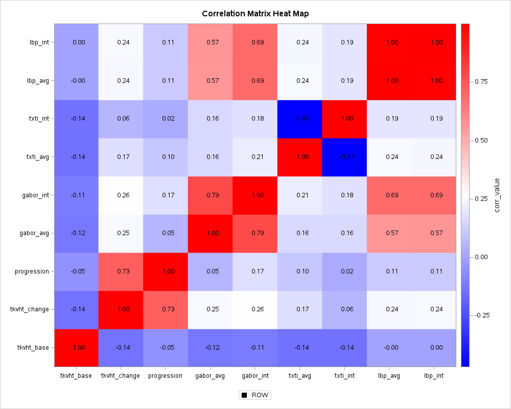

**log**

[output not shown]

## Summary

The strongest correlations for this round are:

- `gabor_int` (r = 0.26)
- `lbp_int` (r = 0.24)

The `txti` average and interaction terms did not perform better than `txti2` alone.

# Feature Engineering III

#### Create Quadratic Terms

```sas
* Create quadratic terms;
DATA Proj3.Data;
    SET Proj3.Data;
    geom1_sq = geom1**2;
    geom2_sq = geom2**2;
    gabor1_sq = gabor1**2;
    gabor2_sq = gabor2**2;
    gabor3_sq = gabor3**2;
    gabor4_sq = gabor4**2;
    gabor5_sq = gabor5**2;
    glcm1_sq = glcm1**2;
    glcm2_sq = glcm2**2;
    txti1_sq = txti1**2;
    txti2_sq = txti2**2;
    txti3_sq = txti3**2;
    txti4_sq = txti4**2;
    txti5_sq = txti5**2;
    lbp1_sq = lbp1**2;
    lbp2_sq = lbp2**2;
    lbp3_sq = lbp3**2;
    lbp4_sq = lbp4**2;
    lbp5_sq = lbp5**2;
    RUN;
```

## Correlation Matrix II

#### Create the Correlation Matrix

```sas
* Print correlation matrix;
PROC CORR DATA = Proj3.Data OUTP = corr_matr;
    VAR tkvht_base tkvht_change progression geom1_sq geom2_sq gabor1_sq gabor2_sq gabor3_sq gabor4_sq gabor5_sq glcm1_sq glcm2_sq txti1_sq txti2_sq txti3_sq txti4_sq txti5_sq lbp1_sq lbp2_sq lbp3_sq lbp4_sq lbp5_sq;
    RUN;

* Create a dataset with only the correlation coefficients;
DATA corr_only;
    SET corr_matr;
    IF _TYPE_ = 'CORR'; /* Select only the rows with correlation coefficients */
RUN;

* Reshape the correlation matrix for the heat map;
DATA heatmap_data;
    SET corr_only;
    ARRAY vars[*] tkvht_base tkvht_change progression geom1_sq geom2_sq gabor1_sq gabor2_sq gabor3_sq gabor4_sq gabor5_sq glcm1_sq glcm2_sq txti1_sq txti2_sq txti3_sq txti4_sq txti5_sq lbp1_sq lbp2_sq lbp3_sq lbp4_sq lbp5_sq;
    DO i = 1 to DIM(vars);
        ROW = _NAME_;
        COL = VNAME(vars[i]);
        corr_value = vars[i];
        IF NOT missing(corr_value) THEN DO;
            LABEL = PUT(corr_value, 8.2); * Format the text label;
            OUTPUT;
        END;
    END;
    KEEP row col corr_value label;
RUN;
```

#### Plot the Correlation Matrix as a Heatmap

```sas
* Set the dimensions of the output graphic;
ODS GRAPHICS / WIDTH=1000px HEIGHT=800px;

* Create the Heat Map;
PROC SGPLOT DATA=heatmap_data;
    HEATMAPPARM X=col Y=row COLORRESPONSE = corr_value / COLORMODEL = (blue white red);
    TEXT X=col Y=row TEXT=label / TEXTATTRS = (SIZE=8) POSITION = center;
    XAXIS DISPLAY = (nolabel) DISCRETEORDER = data;
    YAXIS DISPLAY=(nolabel) DISCRETEORDER = data;
    TITLE "Correlation Matrix Heat Map";
RUN;
```

**lst**

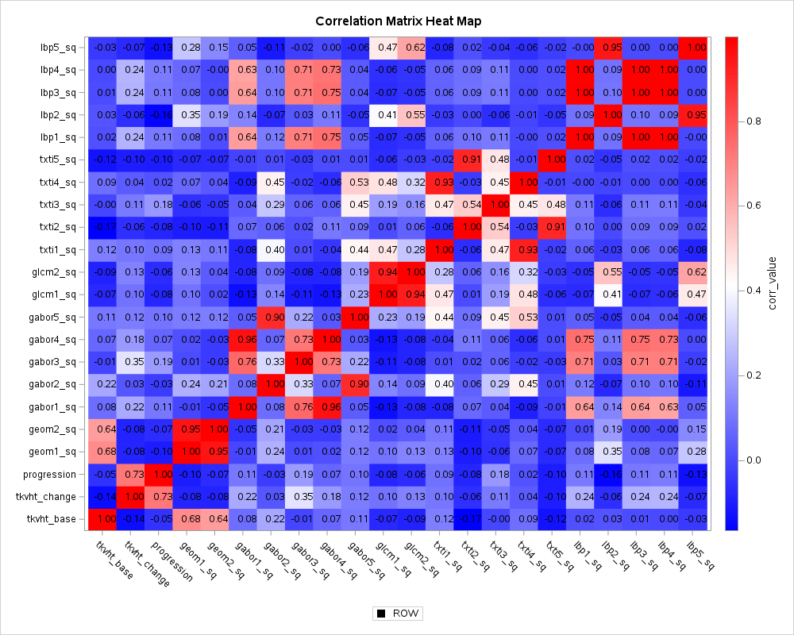

**log**

[output not shown]

## Summary

The only quadratic term that performs better than previous terms is `gabor3_sq` (r = 0.35), which will be chosen instead of `gabor_int`.

## Feature Engineering Summary

The final variables MRI image features chosen are:

- `lbp_int`
- `txti2`
- `gabor3_sq`

# Feature Scaling

Before we perform our regression, we must standardize our variables to place them all on the same scale so that they contribute equally to the model.

This also makes it easier for the gradient descent process to converge faster and more efficiently.

[figure not shown]

## Perform Scaling

#### Standardize All Features

```sas
* Standardize the variables;
PROC STANDARD DATA = Proj3.Data OUT = data_scale MEAN = 0 STD = 1;
    VAR lbp_int txti2 gabor3_sq;
    RUN;
```

# Task One: Linear Regression

## Cost Function

The cost function in a linear regression is Root Mean Square Error (RMSE):

$$\text{RMSE} = \sqrt{\frac{1}{n} \sum_{i=1}^{n} (y_i - \hat{y}_i)^2}$$

Where y is the actual change in outcome variable and y-hat is the predicted change, and n is the number of observations.

#### Mapping Function

In the case of linear regression, the mapping function is essentially each beta in the model.

#### Goal

The goal is to select a mapping function that minimizes the cost function and thereby produces the best predictions for the outcome variable.

## Model 1A: Baseline Kidney Volume

**Analysis**

To answer the researcher’s first question for Task 1, we will perform a predictive model that uses the baseline height-corrected total kidney volume to predict percent change in kidney volume.

```sas
*** Model 1A, Baseline Kidney Volume;
* Perform 5-Fold Cross Validation and Linear Regression;
PROC GLMSELECT DATA = Proj3.Data_scaled PLOTS = ALL SEED = 123;
    PARTITION FRACTION(VALIDATE = 0.2); * Sets up the 5-Fold CV;
    MODEL tkvht_change = tkvht_base / CVMETHOD =  SPLIT(5) SELECTION=none;
    OUTPUT OUT = Model1A PRED = Predicted RESID = Residuals;
    RUN;
```

**lst**

Correlation Matrix Heat Map

The GLMSELECT Procedure

| Data Set | PROJ3.DATA_SCALED |
| --- | --- |
| Dependent Variable | tkvht_change |
| Selection Method | None |
| Random Number Seed | 123 |

| Number of Observations Read | 71 |
| --- | --- |
| Number of Observations Used | 71 |
| Number of Observations Used for Training | 59 |
| Number of Observations Used for Validation | 12 |

| Dimensions |  |
| --- | --- |
| Number of Effects | 2 |
| Number of Parameters | 2 |

Correlation Matrix Heat Map

The GLMSELECT Procedure

| Least Squares Summary Step | Least Squares Summary Effect Entered | Least Squares Summary Number Effects In | Least Squares Summary SBC | Least Squares Summary ASE | Least Squares Summary Validation ASE |
| --- | --- | --- | --- | --- | --- |
| 0 | Intercept | 1 | 244.0296* | 58.3806 | 111.0698 |
| 1 | tkvht_base | 2 | 247.2271 | 57.5163 | 107.9482* |

* Optimal Value of Criterion

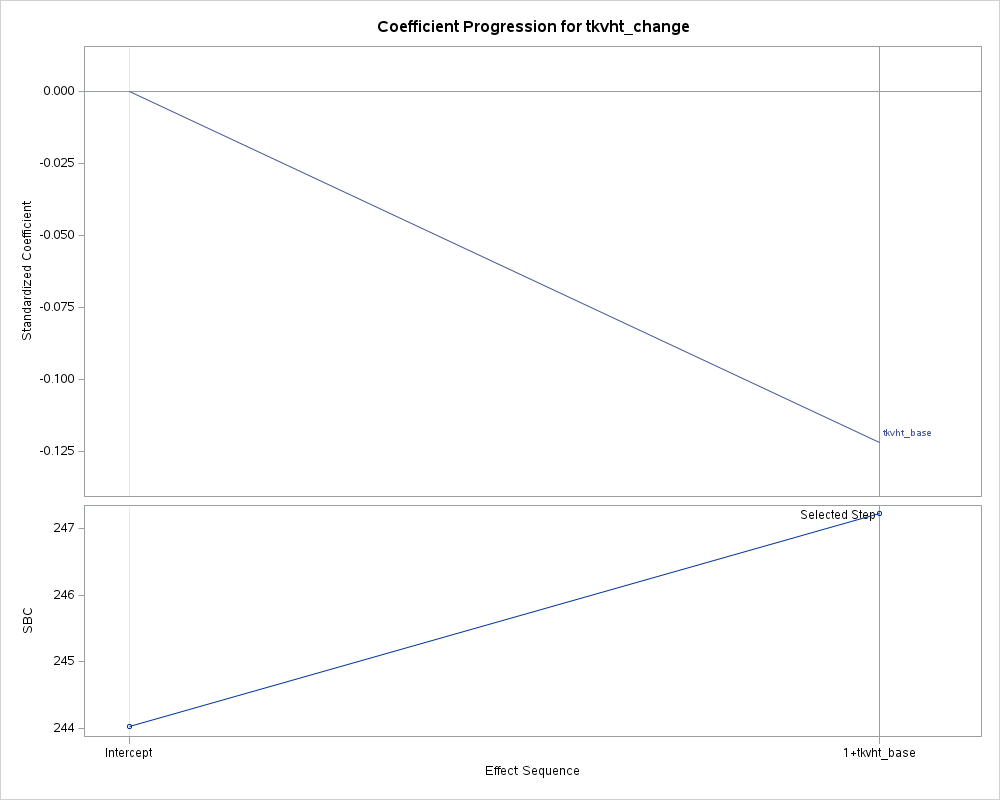

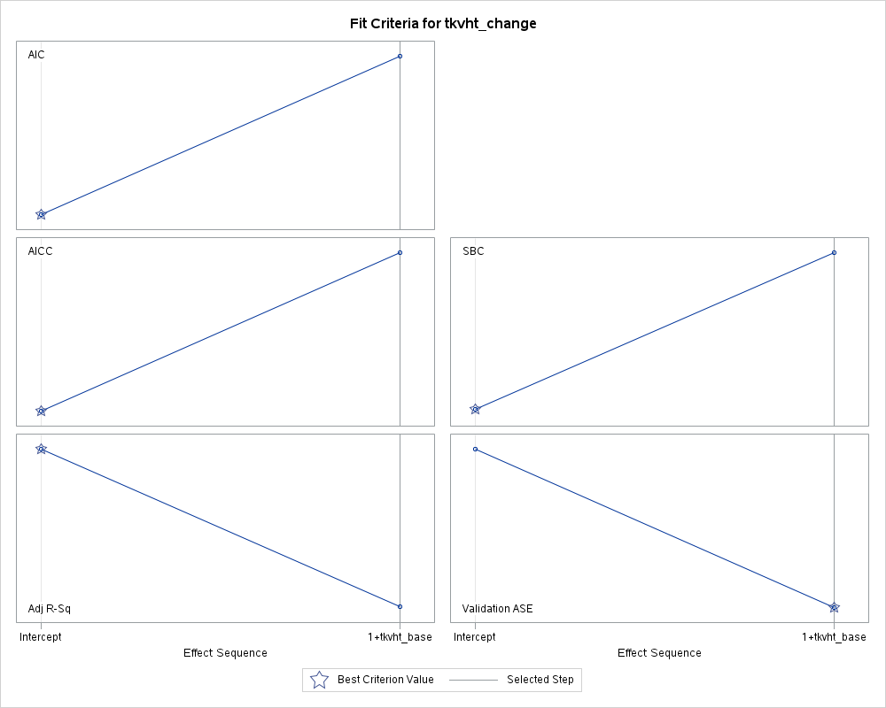

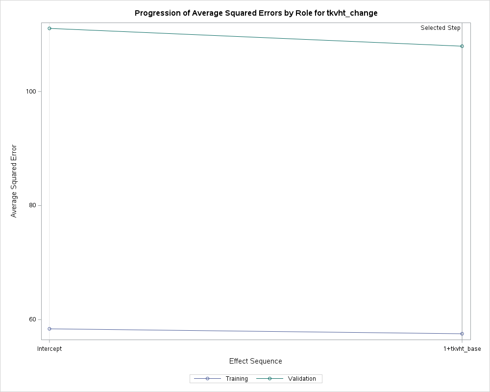

Correlation Matrix Heat Map

The GLMSELECT Procedure

Least Squares Model (No Selection)

| Analysis of Variance Source | Analysis of Variance DF | Analysis of Variance Sum of Squares | Analysis of Variance Mean Square | Analysis of Variance F Value | Analysis of Variance Pr > F |
| --- | --- | --- | --- | --- | --- |
| Model | 1 | 50.99565 | 50.99565 | 0.86 | 0.3586 |
| Error | 57 | 3393.46096 | 59.53440 |  |  |
| Corrected Total | 58 | 3444.45662 |  |  |  |

| Root MSE | 7.71585 |
| --- | --- |
| Dependent Mean | 8.88119 |
| R-Square | 0.0148 |
| Adj R-Sq | -.0025 |
| AIC | 304.07202 |
| AICC | 304.50839 |
| SBC | 247.22710 |
| ASE (Train) | 57.51629 |
| ASE (Validate) | 107.94821 |

| Parameter Estimates Parameter | Parameter Estimates DF | Parameter Estimates Estimate | Parameter Estimates Standard Error | Parameter Estimates t Value | Parameter Estimates Pr > \|t\| |
| --- | --- | --- | --- | --- | --- |
| Intercept | 1 | 10.523955 | 2.039514 | 5.16 | <.0001 |
| tkvht_base | 1 | -0.004515 | 0.004878 | -0.93 | 0.3586 |

**log**

[output not shown]

Top of Tabset

**Visualization**

```sas
* Plot residuals vs. predicted values;
PROC SGPLOT DATA = Model1A;
    SCATTER X=Predicted Y=Residuals;
    REFLINE 0 / AXIS=y LINEATTRS=(pattern=shortdash);
    XAXIS LABEL='Predicted Values';
    YAXIS LABEL='Residuals';
    TITLE 'Residuals vs. Predicted Values';
    RUN;
```

**lst**

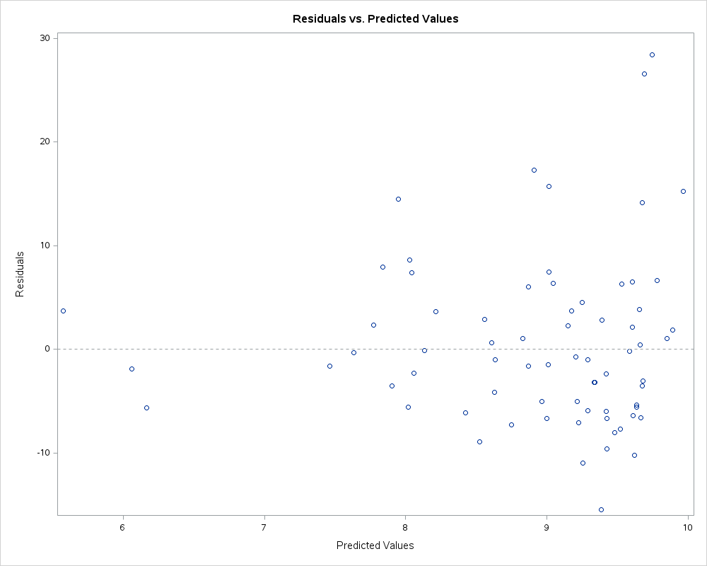

**log**

[output not shown]

Top of Tabset

**Summary**

the RMSE of the model including `kidvol_base` alone is 7.72.

The assumption of normality is almost, but not quite, met.

Top of Tabset

## Model 1B: MRI Features

To answer the researcher’s second question for Task 1, we will run a predictive model that uses only MRI image features to predict percent change in kidney volume at year 3.

$$Kidney Volume Change = 𝛽_0 + 𝛽_1*Txti2 + 𝛽_{2}*LbpInt + e$$

#### Model Selection

The potential scaled covariates for our final model after feature engineering and interactive variable selection are:

- `lbp_int`
- `txti2`
- `gabor3_sq`

**Model Selection**

```sas
** Model 1B: MRI Image Features;
* Perform 5-Fold Cross Validation and Linear Regression;
PROC GLMSELECT DATA = Proj3.Data_scaled PLOTS = ALL SEED = 123;
    PARTITION FRACTION(VALIDATE = 0.2); * Sets up the 5-Fold CV;
    MODEL tkvht_change = lbp_int txti2 gabor3_sq / CVMETHOD =  SPLIT(5) SELECTION = NONE;
    RUN;
```

**lst**

Residuals vs. Predicted Values

The GLMSELECT Procedure

| Data Set | PROJ3.DATA_SCALED |
| --- | --- |
| Dependent Variable | tkvht_change |
| Selection Method | None |
| Random Number Seed | 123 |

| Number of Observations Read | 71 |
| --- | --- |
| Number of Observations Used | 71 |
| Number of Observations Used for Training | 59 |
| Number of Observations Used for Validation | 12 |

| Dimensions |  |
| --- | --- |
| Number of Effects | 4 |
| Number of Parameters | 4 |

Residuals vs. Predicted Values

The GLMSELECT Procedure

| Least Squares Summary Step | Least Squares Summary Effect Entered | Least Squares Summary Number Effects In | Least Squares Summary SBC | Least Squares Summary ASE | Least Squares Summary Validation ASE |
| --- | --- | --- | --- | --- | --- |
| 0 | Intercept | 1 | 244.0296 | 58.3806 | 111.0698 |
| 1 | lbp_int | 2 | 242.6501 | 53.2231 | 113.0121 |
| 2 | txti2 | 3 | 239.2228* | 46.8660 | 102.0524* |
| 3 | gabor3_sq | 4 | 243.2656 | 46.8383 | 106.1342 |

* Optimal Value of Criterion

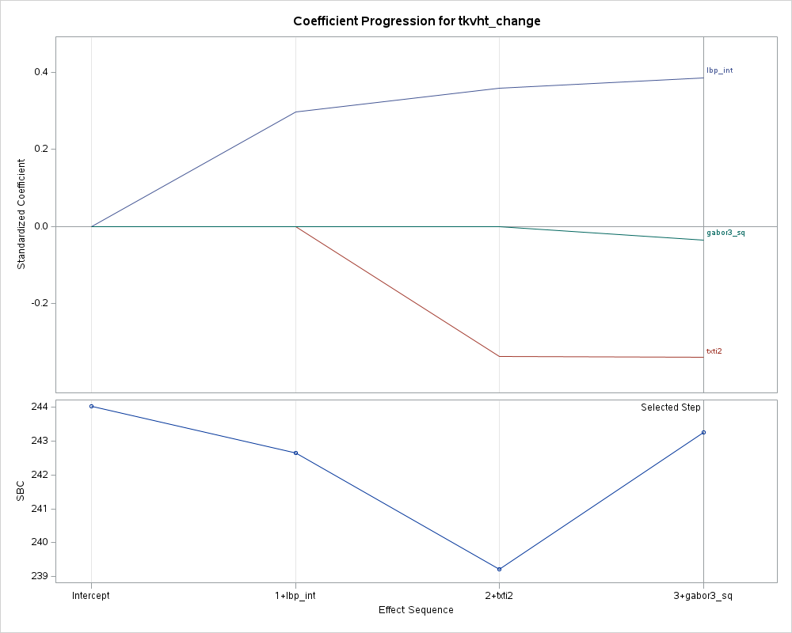

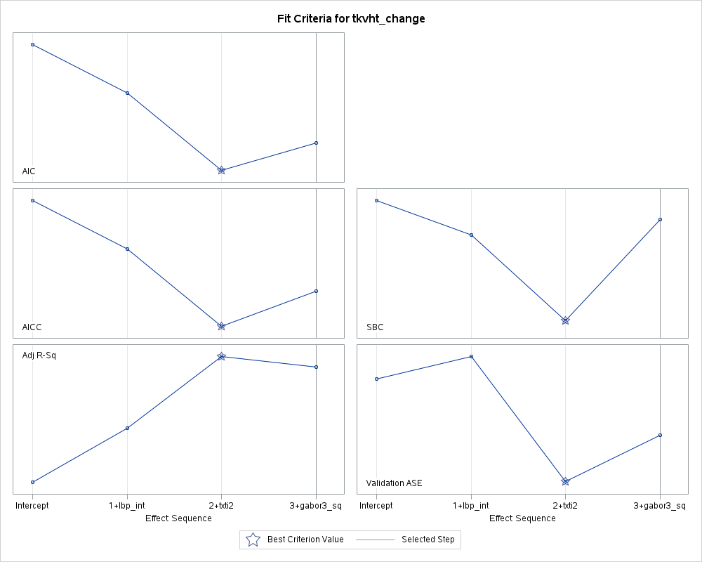

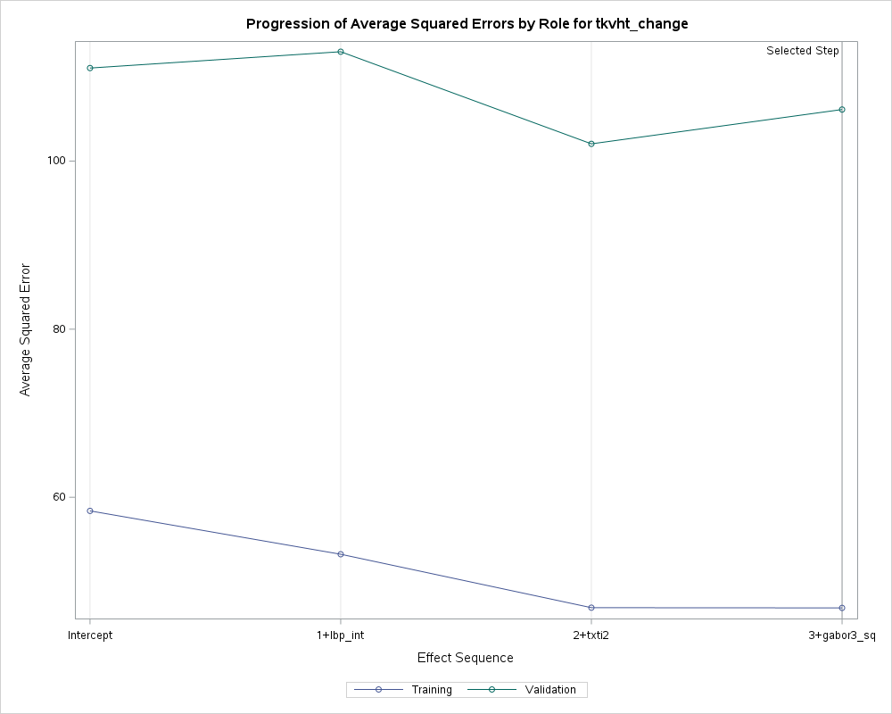

Residuals vs. Predicted Values

The GLMSELECT Procedure

Least Squares Model (No Selection)

| Analysis of Variance Source | Analysis of Variance DF | Analysis of Variance Sum of Squares | Analysis of Variance Mean Square | Analysis of Variance F Value | Analysis of Variance Pr > F |
| --- | --- | --- | --- | --- | --- |
| Model | 3 | 680.99444 | 226.99815 | 4.52 | 0.0067 |
| Error | 55 | 2763.46218 | 50.24477 |  |  |
| Corrected Total | 58 | 3444.45662 |  |  |  |

| Root MSE | 7.08835 |
| --- | --- |
| Dependent Mean | 8.88119 |
| R-Square | 0.1977 |
| Adj R-Sq | 0.1539 |
| AIC | 295.95543 |
| AICC | 297.08750 |
| SBC | 243.26558 |
| ASE (Train) | 46.83834 |
| ASE (Validate) | 106.13419 |

| Parameter Estimates Parameter | Parameter Estimates DF | Parameter Estimates Estimate | Parameter Estimates Standard Error | Parameter Estimates t Value | Parameter Estimates Pr > \|t\| |
| --- | --- | --- | --- | --- | --- |
| Intercept | 1 | 8.980217 | 0.925709 | 9.70 | <.0001 |
| lbp_int | 1 | 2.706174 | 1.368868 | 1.98 | 0.0531 |
| txti2 | 1 | -2.665708 | 0.976472 | -2.73 | 0.0085 |
| gabor3_sq | 1 | -0.261434 | 1.451159 | -0.18 | 0.8577 |

**log**

[output not shown]

Top of Tabset

**Analysis**

```sas
** Model 1B: MRI Image Features;
* Perform 5-Fold Cross Validation and Linear Regression;
PROC GLMSELECT DATA = Proj3.Data_scaled PLOTS = ALL SEED = 123;
    PARTITION FRACTION(VALIDATE = 0.2); * Sets up the 5-Fold CV;
    MODEL tkvht_change = lbp_int txti2 / CVMETHOD =  SPLIT(5) SELECTION = NONE;
    OUTPUT OUT = Model1B PRED = Predicted RESID = Residuals;
    RUN;
```

**lst**

Residuals vs. Predicted Values

The GLMSELECT Procedure

| Data Set | PROJ3.DATA_SCALED |
| --- | --- |
| Dependent Variable | tkvht_change |
| Selection Method | None |
| Random Number Seed | 123 |

| Number of Observations Read | 71 |
| --- | --- |
| Number of Observations Used | 71 |
| Number of Observations Used for Training | 59 |
| Number of Observations Used for Validation | 12 |

| Dimensions |  |
| --- | --- |
| Number of Effects | 3 |
| Number of Parameters | 3 |

Residuals vs. Predicted Values

The GLMSELECT Procedure

| Least Squares Summary Step | Least Squares Summary Effect Entered | Least Squares Summary Number Effects In | Least Squares Summary SBC | Least Squares Summary ASE | Least Squares Summary Validation ASE |
| --- | --- | --- | --- | --- | --- |
| 0 | Intercept | 1 | 244.0296 | 58.3806 | 111.0698 |
| 1 | lbp_int | 2 | 242.6501 | 53.2231 | 113.0121 |
| 2 | txti2 | 3 | 239.2228* | 46.8660 | 102.0524* |

* Optimal Value of Criterion

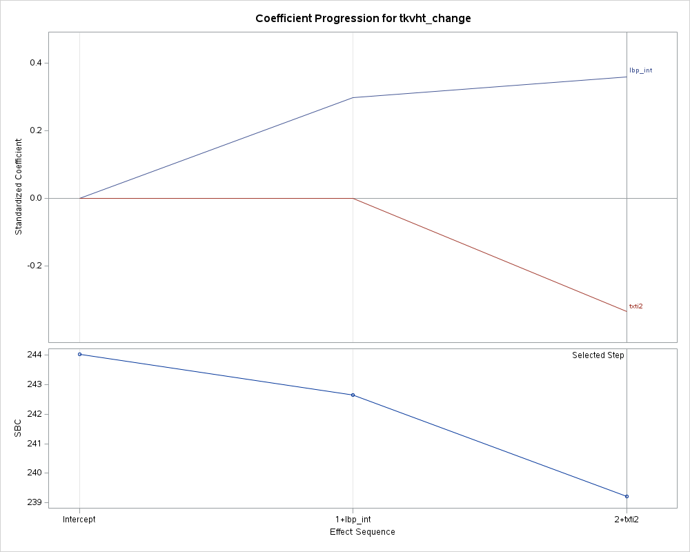

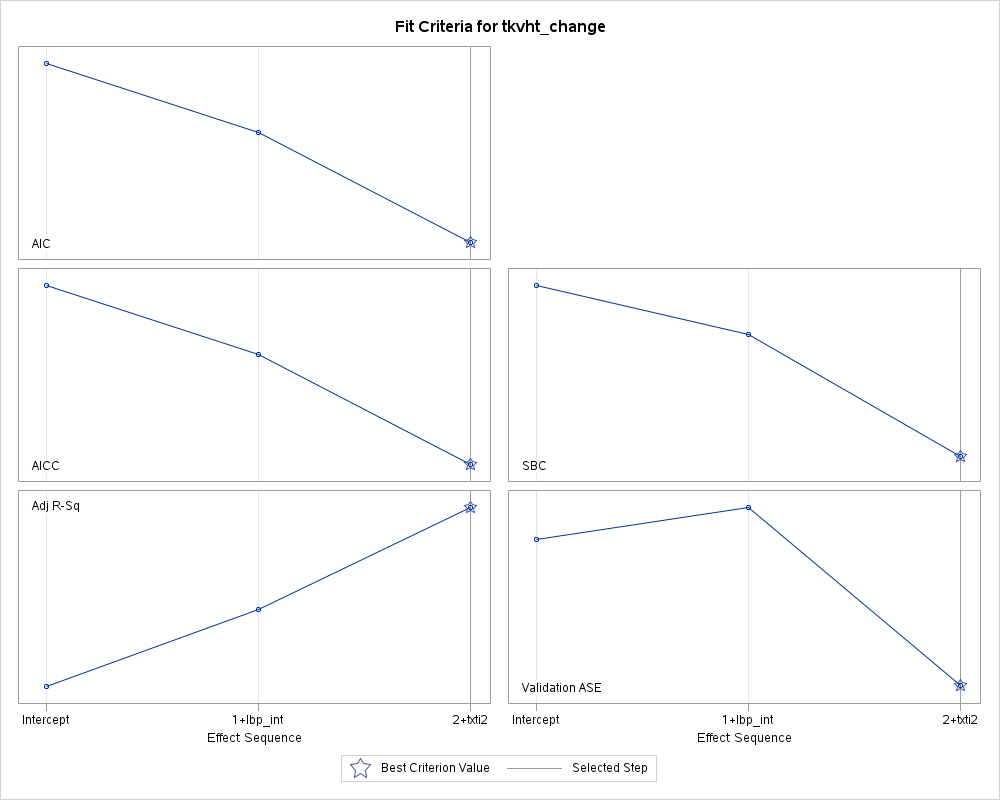

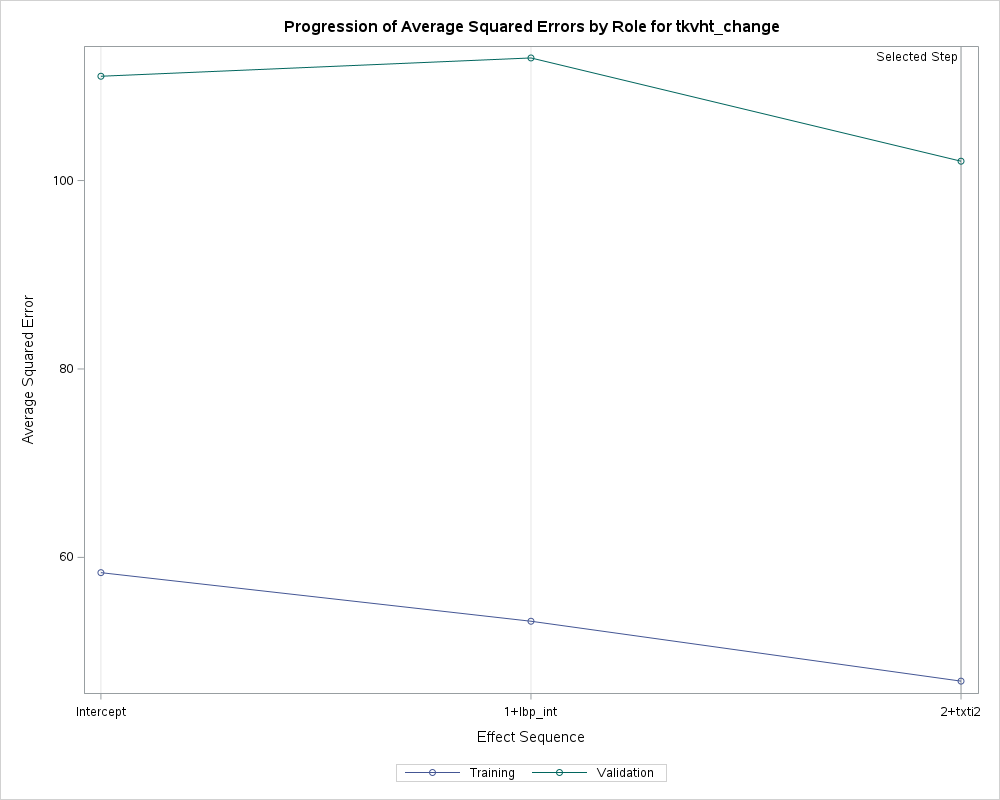

Residuals vs. Predicted Values

The GLMSELECT Procedure

Least Squares Model (No Selection)

| Analysis of Variance Source | Analysis of Variance DF | Analysis of Variance Sum of Squares | Analysis of Variance Mean Square | Analysis of Variance F Value | Analysis of Variance Pr > F |
| --- | --- | --- | --- | --- | --- |
| Model | 2 | 679.36370 | 339.68185 | 6.88 | 0.0021 |
| Error | 56 | 2765.09292 | 49.37666 |  |  |
| Corrected Total | 58 | 3444.45662 |  |  |  |

| Root MSE | 7.02685 |
| --- | --- |
| Dependent Mean | 8.88119 |
| R-Square | 0.1972 |
| Adj R-Sq | 0.1686 |
| AIC | 293.99023 |
| AICC | 294.73097 |
| SBC | 239.22284 |
| ASE (Train) | 46.86598 |
| ASE (Validate) | 102.05238 |

| Parameter Estimates Parameter | Parameter Estimates DF | Parameter Estimates Estimate | Parameter Estimates Standard Error | Parameter Estimates t Value | Parameter Estimates Pr > \|t\| |
| --- | --- | --- | --- | --- | --- |
| Intercept | 1 | 8.987483 | 0.916805 | 9.80 | <.0001 |
| lbp_int | 1 | 2.514704 | 0.855219 | 2.94 | 0.0048 |
| txti2 | 1 | -2.640614 | 0.958101 | -2.76 | 0.0079 |

**log**

[output not shown]

Top of Tabset

**Visualization**

```sas
* Plot residuals vs. predicted values;
PROC SGPLOT DATA = Model1B;
    SCATTER X=Predicted Y=Residuals;
    REFLINE 0 / AXIS=y LINEATTRS=(pattern=shortdash);
    XAXIS LABEL='Predicted Values';
    YAXIS LABEL='Residuals';
    TITLE 'Residuals vs. Predicted Values';
    RUN;
```

**lst**

<!DOCTYPE html>

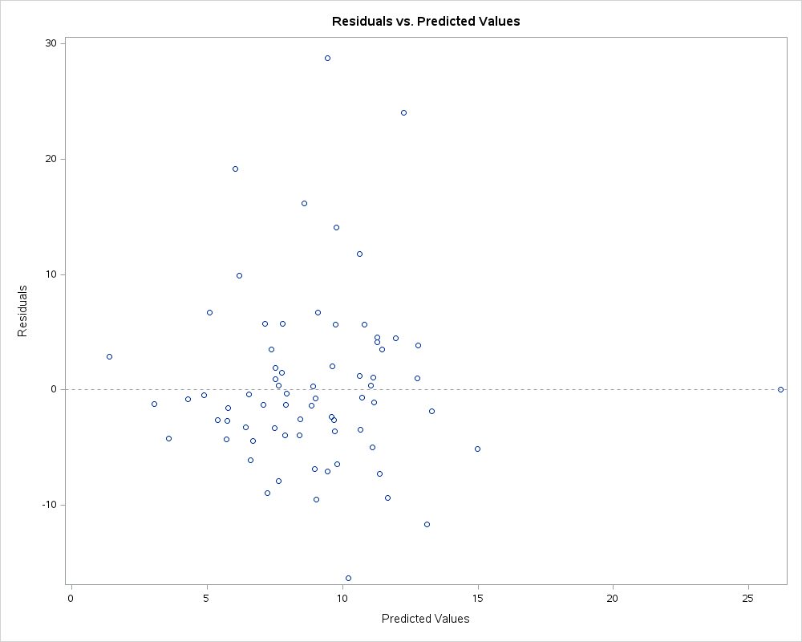

**log**

```
41                                                         The SAS System                      Friday, December 19, 2025 03:53:00 AM

477        ods listing close;ods html5 (id=saspy_internal) file=_tomods1 options(bitmap_mode='inline') device=svg style=HTMLBlue;
477      ! ods graphics on / outputfmt=png;
478
479        * Plot residuals vs. predicted values;
480        PROC SGPLOT DATA = Model1B;
481            SCATTER X=Predicted Y=Residuals;
482            REFLINE 0 / AXIS=y LINEATTRS=(pattern=shortdash);
483            XAXIS LABEL='Predicted Values';
484            YAXIS LABEL='Residuals';
485            TITLE 'Residuals vs. Predicted Values';
486         RUN;
487
488
489        ods html5 (id=saspy_internal) close;ods listing;
490
42                                                         The SAS System                      Friday, December 19, 2025 03:53:00 AM

491
```

Top of Tabset

**Summary**

The RMSE for the model including only MRI Image features was 7.02, with both `lbp_int` and `txti2` being highly significant predictors of `tkvht_change`.

Top of Tabset

## Model 1C: Baseline Kidney Volume and MRI Image Features

**Analysis**

To answer the researcher’s third question, we will run a predictive model that uses the baseline height-corrected total kidney volume AND MRI image features to predict percent change in kidney volume.

$$Kidney Volume Change = 𝛽_0 + 𝛽_{1}*Baseline Kidney Volume + 𝛽_{2}*Txti2 + 𝛽_{3}*LbpInt + e$$

```sas
** Model 1C: Baseline + MRI Image Features;
* Perform 5-Fold Cross Validation and Linear Regression;
PROC GLMSELECT DATA = Proj3.Data_scaled PLOTS = ALL SEED = 123;
    PARTITION FRACTION(VALIDATE = 0.2); * Sets up the 5-Fold CV;
    MODEL tkvht_change = tkvht_base lbp_int txti2 / CVMETHOD =  SPLIT(5) SELECTION = NONE;
    OUTPUT OUT = Model1C PRED = Predicted RESID = Residuals;
    RUN;
```

**lst**

<!DOCTYPE html>

Residuals vs. Predicted Values

The GLMSELECT Procedure

| Data Set | PROJ3.DATA_SCALED |
| --- | --- |
| Dependent Variable | tkvht_change |
| Selection Method | None |
| Random Number Seed | 123 |

| Number of Observations Read | 71 |
| --- | --- |
| Number of Observations Used | 71 |
| Number of Observations Used for Training | 59 |
| Number of Observations Used for Validation | 12 |

| Dimensions |  |
| --- | --- |
| Number of Effects | 4 |
| Number of Parameters | 4 |

Residuals vs. Predicted Values

The GLMSELECT Procedure

| Least Squares Summary Step | Least Squares Summary Effect Entered | Least Squares Summary Number Effects In | Least Squares Summary SBC | Least Squares Summary ASE | Least Squares Summary Validation ASE |
| --- | --- | --- | --- | --- | --- |
| 0 | Intercept | 1 | 244.0296 | 58.3806 | 111.0698 |
| 1 | tkvht_base | 2 | 247.2271 | 57.5163 | 107.9482 |
| 2 | lbp_int | 3 | 245.7787 | 52.3739 | 109.7687 |
| 3 | txti2 | 4 | 241.7845* | 45.6772 | 97.1320* |

* Optimal Value of Criterion

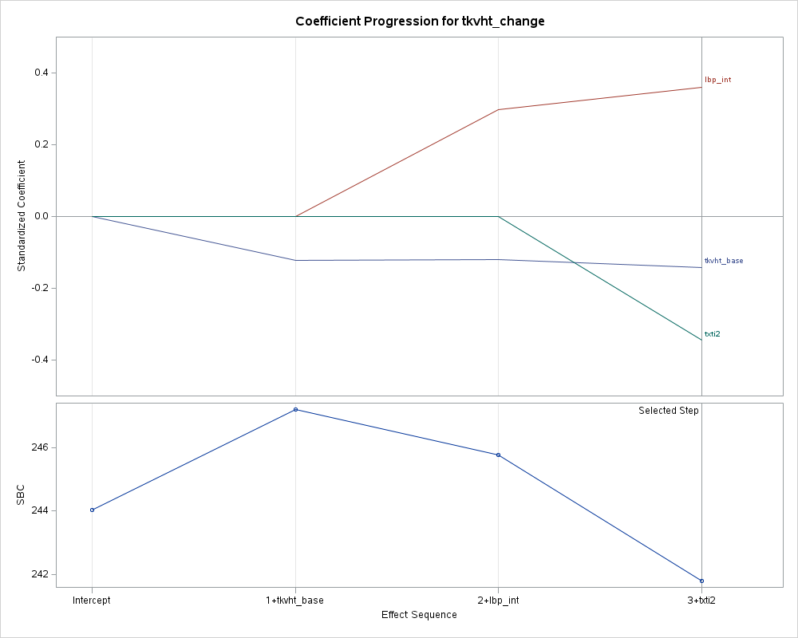

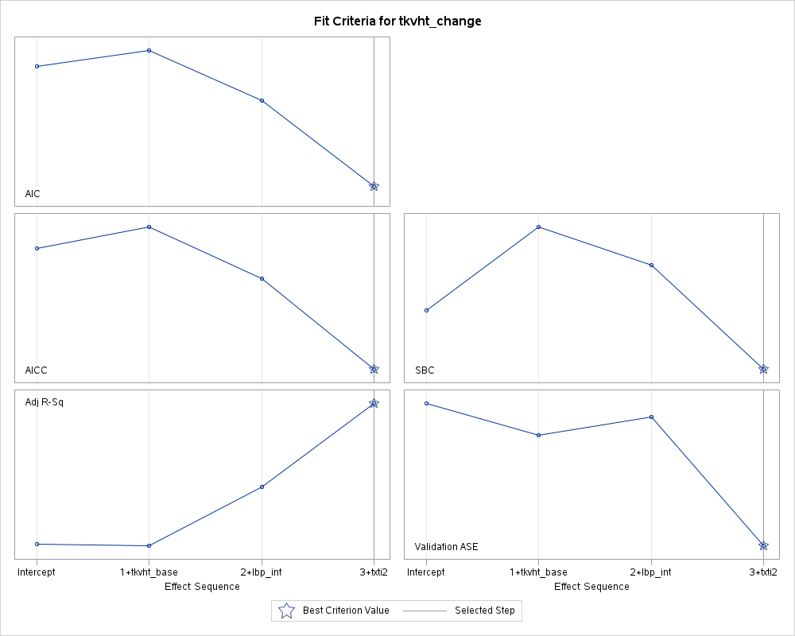

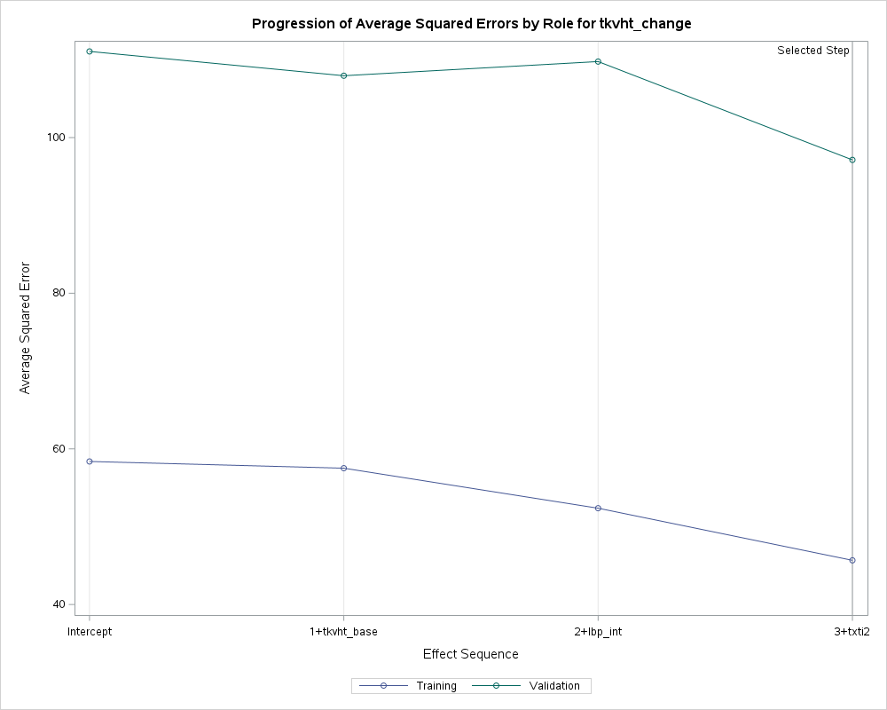

Residuals vs. Predicted Values

The GLMSELECT Procedure

Least Squares Model (No Selection)

| Analysis of Variance Source | Analysis of Variance DF | Analysis of Variance Sum of Squares | Analysis of Variance Mean Square | Analysis of Variance F Value | Analysis of Variance Pr > F |
| --- | --- | --- | --- | --- | --- |
| Model | 3 | 749.50019 | 249.83340 | 5.10 | 0.0035 |
| Error | 55 | 2694.95643 | 48.99921 |  |  |
| Corrected Total | 58 | 3444.45662 |  |  |  |

| Root MSE | 6.99994 |
| --- | --- |
| Dependent Mean | 8.88119 |
| R-Square | 0.2176 |
| Adj R-Sq | 0.1749 |
| AIC | 294.47439 |
| AICC | 295.60647 |
| SBC | 241.78454 |
| ASE (Train) | 45.67723 |
| ASE (Validate) | 97.13202 |

| Parameter Estimates Parameter | Parameter Estimates DF | Parameter Estimates Estimate | Parameter Estimates Standard Error | Parameter Estimates t Value | Parameter Estimates Pr > \|t\| |
| --- | --- | --- | --- | --- | --- |
| Intercept | 1 | 10.922833 | 1.857650 | 5.88 | <.0001 |
| tkvht_base | 1 | -0.005306 | 0.004435 | -1.20 | 0.2367 |
| lbp_int | 1 | 2.523276 | 0.851974 | 2.96 | 0.0045 |
| txti2 | 1 | -2.716157 | 0.956518 | -2.84 | 0.0063 |

**log**

```
43                                                         The SAS System                      Friday, December 19, 2025 03:53:00 AM

494        ods listing close;ods html5 (id=saspy_internal) file=_tomods1 options(bitmap_mode='inline') device=svg style=HTMLBlue;
494      ! ods graphics on / outputfmt=png;
495
496        ** Model 1C: Baseline + MRI Image Features;
497        * Perform 5-Fold Cross Validation and Linear Regression;
498        PROC GLMSELECT DATA = Proj3.Data_scaled PLOTS = ALL SEED = 123;
499         PARTITION FRACTION(VALIDATE = 0.2); * Sets up the 5-Fold CV;
500         MODEL tkvht_change = tkvht_base lbp_int txti2 / CVMETHOD =  SPLIT(5) SELECTION = NONE;
501         OUTPUT OUT = Model1C PRED = Predicted RESID = Residuals;
502         RUN;
503
504
505        ods html5 (id=saspy_internal) close;ods listing;
506
44                                                         The SAS System                      Friday, December 19, 2025 03:53:00 AM

507
```

Top of Tabset

**Visualization**

```sas
* Plot residuals vs. predicted values;
PROC SGPLOT DATA = Model1C;
    SCATTER X=Predicted Y=Residuals;
    REFLINE 0 / AXIS=y LINEATTRS=(pattern=shortdash);
    XAXIS LABEL='Predicted Values';
    YAXIS LABEL='Residuals';
    TITLE 'Residuals vs. Predicted Values';
    RUN;
```

**lst**

<!DOCTYPE html>

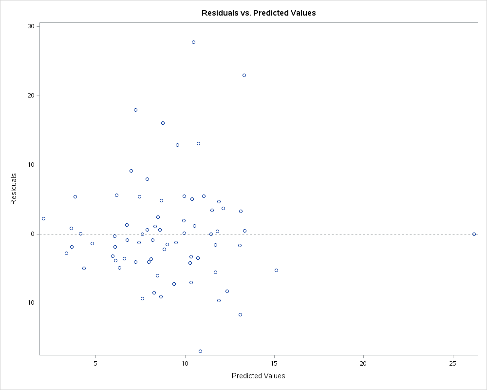

**log**

```
45                                                         The SAS System                      Friday, December 19, 2025 03:53:00 AM

510        ods listing close;ods html5 (id=saspy_internal) file=_tomods1 options(bitmap_mode='inline') device=svg style=HTMLBlue;
510      ! ods graphics on / outputfmt=png;
511
512        * Plot residuals vs. predicted values;
513        PROC SGPLOT DATA = Model1C;
514            SCATTER X=Predicted Y=Residuals;
515            REFLINE 0 / AXIS=y LINEATTRS=(pattern=shortdash);
516            XAXIS LABEL='Predicted Values';
517            YAXIS LABEL='Residuals';
518            TITLE 'Residuals vs. Predicted Values';
519         RUN;
520
521
522        ods html5 (id=saspy_internal) close;ods listing;
523
46                                                         The SAS System                      Friday, December 19, 2025 03:53:00 AM

524
```

Top of Tabset

**Summary**

Model 1C with baseline kidney volume and MRI image features (MRSE = 7.00) did not perform better than model 1B using MRI image features alone (MRSE = 7.02).

Top of Tabset

## Model Comparison

Here we will compare how models 1A, 1B, and 1C performed.

### Final Average RMSE

| Model | RMSE |
| --- | --- |
| 1A: Baseline Kidney Volume | 7.72 |
| 1B: MRI Image Features | 7.02 |
| 1C Baseline Kidney Volume and MRI | 7.00 |

## Conclusion

The differences in model performance for task one were not statistically significant. Model A had an RMSE that was 0.70 points higher than model B, and 0.72 points higher than model C.

Thus, **including MRI image features into the predictive model slightly increased predictive capability** above and beyond that of just using kidney volume measurements at baseline.

# Task Two: Logistic Regression

Here we will perform the logistic regression predicting disease progression as `fast` or `slow`.

We will first create a macro to perform 5-fold cross validation in these analyses (code adapted from ChatGPT)

#### Create 5 Folds

```sas
* Create cross validation folds;
DATA Proj3.Data_Scaled;
    SET Proj3.Data_Scaled;
    fold = mod(_N_, 5) + 1;
    RUN;
```

#### Create Analysis Macro

```sas
* Define a macro to perform the cross validation analyses;
%MACRO cross_validate(data=, target=, predictors=);
    %DO fold = 1 %TO 5;
        /* Split data into training and validation sets */
        DATA train valid;
            SET &data;
            IF fold ne &fold THEN OUTPUT train;
            ELSE OUTPUT valid;
        RUN;

        /* Train the model on the training set */
        PROC LOGISTIC DATA=train;
            MODEL &target(EVENT='Fast') = &predictors;
            OUTPUT=pred_train P=pred;
        run;

        /* Validate the model on the validation set */
       PROC LOGISTIC DATA = valid;
            MODEL &target(EVENT='Fast') = &predictors;
            OUTPUT OUT=pred_valid P=pred;
        run;

        /* Store the validation results */
        DATA results_&fold;
            SET pred_valid;
            IF fold = . THEN fold = &fold;
        RUN;
    %END;

    /* Combine the results from all folds */
    DATA all_results;
        SET results_:;
    RUN;
%MEND cross_validate;
```

## Model 2A

### Baseline Kidney Volume

To answer the researcher’s first question for this task, we will run a predictive model that uses the baseline height-corrected total kidney volume to predict whether a patient had fast or slow disease progression.

$$logit(Progression) = 𝛽_0 + 𝛽_1*{Baseline Kidney Volume} + e$$

**Analysis**

#### Train the Model

```sas
* Run Model;
%cross_validate(data=Proj3.Data_scaled, target=progression, predictors=tkvht_base);
```

#### Acquire AUC and ROC Curve

```sas
*ODS TRACE ON;
ODS EXCLUDE ModelInfo NOBS ResponseProfile ConvergenceStatus ROCcurve;
/* Calculate ROC curve and AUC the each model */
PROC LOGISTIC DATA = all_results;
    MODEL progression(EVENT = 'Fast') = tkvht_base;
    OUTPUT OUT = Model2A PREDICTED = Model2Apred;
    ROC;
RUN;
*ODS TRACE OFF;
```

**lst**

<!DOCTYPE html>

Residuals vs. Predicted Values

The LOGISTIC Procedure

| Model Fit Statistics Criterion | Model Fit Statistics Intercept Only | Model Fit Statistics Intercept and Covariates |
| --- | --- | --- |
| AIC | 100.300 | 102.109 |
| SC | 102.563 | 106.634 |
| -2 Log L | 98.300 | 98.109 |

| Testing Global Null Hypothesis: BETA=0 Test | Testing Global Null Hypothesis: BETA=0 Chi-Square | Testing Global Null Hypothesis: BETA=0 DF | Testing Global Null Hypothesis: BETA=0 Pr > ChiSq |
| --- | --- | --- | --- |
| Likelihood Ratio | 0.1913 | 1 | 0.6619 |
| Score | 0.1912 | 1 | 0.6619 |
| Wald | 0.1901 | 1 | 0.6628 |

| Analysis of Maximum Likelihood Estimates Parameter | Analysis of Maximum Likelihood Estimates DF | Analysis of Maximum Likelihood Estimates Estimate | Analysis of Maximum Likelihood Estimates Standard Error | Analysis of Maximum Likelihood Estimates Wald Chi-Square | Analysis of Maximum Likelihood Estimates Pr > ChiSq |
| --- | --- | --- | --- | --- | --- |
| Intercept | 1 | 0.2730 | 0.4932 | 0.3065 | 0.5798 |
| tkvht_base | 1 | -0.00053 | 0.00122 | 0.1901 | 0.6628 |

| Odds Ratio Estimates Effect | Odds Ratio Estimates Point Estimate | Odds Ratio Estimates 95% Wald Confidence Limits | Odds Ratio Estimates 95% Wald Confidence Limits |
| --- | --- | --- | --- |
| tkvht_base | 0.999 | 0.997 | 1.002 |

ROC Model: ROC1

| -2 Log L | = | 98.300 |
| --- | --- | --- |

| Analysis of Maximum Likelihood Estimates Parameter | Analysis of Maximum Likelihood Estimates DF | Analysis of Maximum Likelihood Estimates Estimate | Analysis of Maximum Likelihood Estimates Standard Error | Analysis of Maximum Likelihood Estimates Wald Chi-Square | Analysis of Maximum Likelihood Estimates Pr > ChiSq |
| --- | --- | --- | --- | --- | --- |
| Intercept | 1 | 0.0846 | 0.2376 | 0.1267 | 0.7219 |

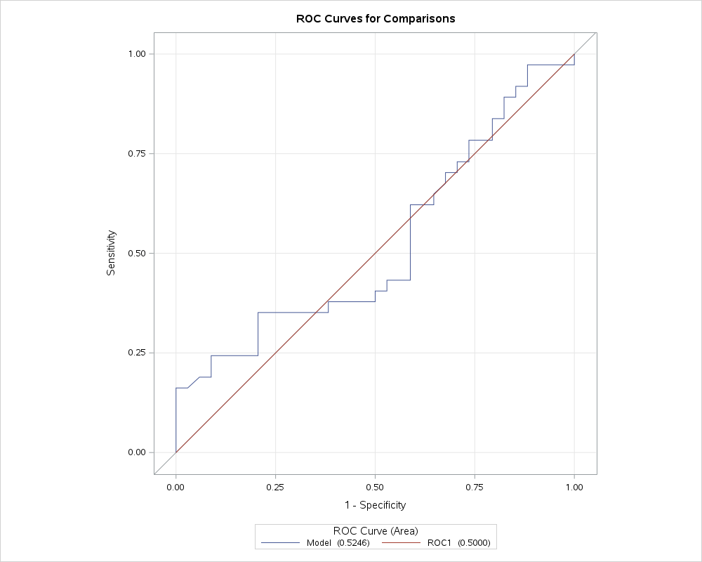

| ROC Association Statistics ROC Model | ROC Association Statistics Mann-Whitney Area | ROC Association Statistics Mann-Whitney Standard Error | ROC Association Statistics Mann-Whitney 95% Wald Confidence Limits | ROC Association Statistics Mann-Whitney 95% Wald Confidence Limits | ROC Association Statistics Somers' D | ROC Association Statistics Gamma | ROC Association Statistics Tau-a |  |  |  |
| --- | --- | --- | --- | --- | --- | --- | --- | --- | --- | --- |
| Model | 0.5246 | 0.0703 | 0.3868 | 0.6625 |  |  |  | 0.0493 | 0.0494 | 0.0249 |
| ROC1 | 0.5000 | 0 | 0.5000 | 0.5000 | 0 | . | 0 |  |  |  |

**log**

```
53                                                         The SAS System                      Friday, December 19, 2025 03:53:00 AM

595        ods listing close;ods html5 (id=saspy_internal) file=_tomods1 options(bitmap_mode='inline') device=svg style=HTMLBlue;
595      ! ods graphics on / outputfmt=png;
596
597        *ODS TRACE ON;
598        ODS EXCLUDE ModelInfo NOBS ResponseProfile ConvergenceStatus ROCcurve;
599        /* Calculate ROC curve and AUC the each model */
600        PROC LOGISTIC DATA = all_results;
601            MODEL progression(EVENT = 'Fast') = tkvht_base;
602            OUTPUT OUT = Model2A PREDICTED = Model2Apred;
603            ROC;
604        RUN;
605        *ODS TRACE OFF;
606
607
608        ods html5 (id=saspy_internal) close;ods listing;
609
54                                                         The SAS System                      Friday, December 19, 2025 03:53:00 AM

610
```

Top of Tabset

**Summary**

The AUC for the model with baseline kidney volume alone was 0.52, essentially just guessing.

Top of Tabset

## Model 2B: MRI Image Features

To answer the researcher’s second question for this task, we will run a predictive model that uses the MRI features to predict whether a patient had fast or slow disease progression.

$$logit(Progression) = 𝛽_0 + 𝛽_1*Txti2 + 𝛽_2*LbpInt + e$$

As the correlation matrices revealed similar relationship between the MRI image features and `progression` as they did with `kidvol_change`, we will use the same final variables as in task model 1B.

These are:

- `lbp_int`
- `txti2`

**Analysis**

#### Train the Model

```sas
* Train Model;
%cross_validate(data=Proj3.Data_scaled, target=progression, predictors=lbp_int txti2);
```

#### Acquire AUC and ROC Curve

```sas
**** Model 2B;
ODS EXCLUDE ModelInfo NOBS ResponseProfile ConvergenceStatus ROCcurve;
/* Calculate ROC curve and AUC for the model */
PROC LOGISTIC DATA = all_results;
    MODEL progression(EVENT = 'Fast') = lbp_int txti2;
    OUTPUT OUT = Model2B PREDICTED = Model2Bpred;
    ROC;
RUN;
```

**lst**

<!DOCTYPE html>

Residuals vs. Predicted Values

The LOGISTIC Procedure

| Model Fit Statistics Criterion | Model Fit Statistics Intercept Only | Model Fit Statistics Intercept and Covariates |
| --- | --- | --- |
| AIC | 100.300 | 92.067 |
| SC | 102.563 | 98.855 |
| -2 Log L | 98.300 | 86.067 |

| Testing Global Null Hypothesis: BETA=0 Test | Testing Global Null Hypothesis: BETA=0 Chi-Square | Testing Global Null Hypothesis: BETA=0 DF | Testing Global Null Hypothesis: BETA=0 Pr > ChiSq |
| --- | --- | --- | --- |
| Likelihood Ratio | 12.2331 | 2 | 0.0022 |
| Score | 11.0650 | 2 | 0.0040 |
| Wald | 8.8090 | 2 | 0.0122 |

| Analysis of Maximum Likelihood Estimates Parameter | Analysis of Maximum Likelihood Estimates DF | Analysis of Maximum Likelihood Estimates Estimate | Analysis of Maximum Likelihood Estimates Standard Error | Analysis of Maximum Likelihood Estimates Wald Chi-Square | Analysis of Maximum Likelihood Estimates Pr > ChiSq |
| --- | --- | --- | --- | --- | --- |
| Intercept | 1 | 0.1701 | 0.8343 | 0.0415 | 0.8385 |
| lbp_int | 1 | 1.1025 | 6.6925 | 0.0271 | 0.8692 |
| txti2 | 1 | -0.9018 | 0.3042 | 8.7881 | 0.0030 |

| Odds Ratio Estimates Effect | Odds Ratio Estimates Point Estimate | Odds Ratio Estimates 95% Wald Confidence Limits | Odds Ratio Estimates 95% Wald Confidence Limits |
| --- | --- | --- | --- |
| lbp_int | 3.012 | <0.001 | >999.999 |
| txti2 | 0.406 | 0.224 | 0.737 |

ROC Model: ROC1

| -2 Log L | = | 98.300 |
| --- | --- | --- |

| Analysis of Maximum Likelihood Estimates Parameter | Analysis of Maximum Likelihood Estimates DF | Analysis of Maximum Likelihood Estimates Estimate | Analysis of Maximum Likelihood Estimates Standard Error | Analysis of Maximum Likelihood Estimates Wald Chi-Square | Analysis of Maximum Likelihood Estimates Pr > ChiSq |
| --- | --- | --- | --- | --- | --- |
| Intercept | 1 | 0.0846 | 0.2376 | 0.1267 | 0.7219 |

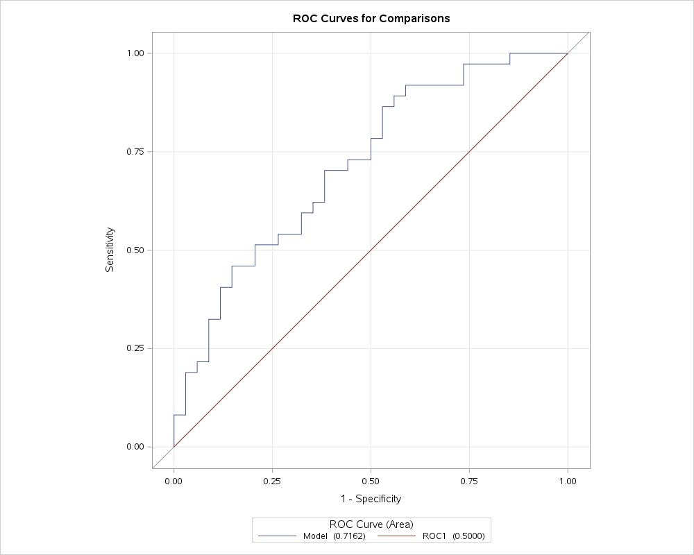

| ROC Association Statistics ROC Model | ROC Association Statistics Mann-Whitney Area | ROC Association Statistics Mann-Whitney Standard Error | ROC Association Statistics Mann-Whitney 95% Wald Confidence Limits | ROC Association Statistics Mann-Whitney 95% Wald Confidence Limits | ROC Association Statistics Somers' D | ROC Association Statistics Gamma | ROC Association Statistics Tau-a |  |  |  |
| --- | --- | --- | --- | --- | --- | --- | --- | --- | --- | --- |
| Model | 0.7162 | 0.0609 | 0.5969 | 0.8355 |  |  |  | 0.4324 | 0.4324 | 0.2189 |
| ROC1 | 0.5000 | 0 | 0.5000 | 0.5000 | 0 | . | 0 |  |  |  |

**log**

```
57                                                         The SAS System                      Friday, December 19, 2025 03:53:00 AM

624        ods listing close;ods html5 (id=saspy_internal) file=_tomods1 options(bitmap_mode='inline') device=svg style=HTMLBlue;
624      ! ods graphics on / outputfmt=png;
625
626        **** Model 2B;
627        ODS EXCLUDE ModelInfo NOBS ResponseProfile ConvergenceStatus ROCcurve;
628        /* Calculate ROC curve and AUC for the model */
629        PROC LOGISTIC DATA = all_results;
630            MODEL progression(EVENT = 'Fast') = lbp_int txti2;
631            OUTPUT OUT = Model2B PREDICTED = Model2Bpred;
632            ROC;
633        RUN;
634
635
636        ods html5 (id=saspy_internal) close;ods listing;
637
58                                                         The SAS System                      Friday, December 19, 2025 03:53:00 AM

638
```

Top of Tabset

**Summary**

The AUC for the model with only MRI image features was 0.72, MUCH better performance than the model with just baseline kidney volume.

Top of Tabset

## Model 2C: Baseline Kidney Volume and MRI Image Features

To answer the researcher’s third question, we will run a predictive model that uses the baseline height-corrected total kidney volume AND MRI image features to predict slow vs fast disease progression.

$$logit(Progression) = 𝛽_0 + 𝛽_1*Baseline Kidney Volume + 𝛽_2*Txti2 + 𝛽_3*LbpInt ... + e$$

**Analysis**

#### Train the Model

```sas
* Train Model;
%cross_validate(data=Proj3.Data_scaled, target=progression, predictors=tkvht_base lbp_int txti2);
```

#### Acquire AUC and ROC Curve

```sas
**** Model 2C;
ODS EXCLUDE ModelInfo NOBS ResponseProfile ConvergenceStatus ROCcurve;
/* Calculate ROC curve and AUC for the model */
PROC LOGISTIC DATA = all_results;
    MODEL progression(EVENT = 'Fast') = tkvht_base lbp_int txti2;
    OUTPUT OUT = Model2C PREDICTED = Model2Cpred;
    ROC;
RUN;
```

**lst**

<!DOCTYPE html>

Residuals vs. Predicted Values

The LOGISTIC Procedure

| Model Fit Statistics Criterion | Model Fit Statistics Intercept Only | Model Fit Statistics Intercept and Covariates |
| --- | --- | --- |
| AIC | 100.300 | 93.520 |
| SC | 102.563 | 102.571 |
| -2 Log L | 98.300 | 85.520 |

| Testing Global Null Hypothesis: BETA=0 Test | Testing Global Null Hypothesis: BETA=0 Chi-Square | Testing Global Null Hypothesis: BETA=0 DF | Testing Global Null Hypothesis: BETA=0 Pr > ChiSq |
| --- | --- | --- | --- |
| Likelihood Ratio | 12.7797 | 3 | 0.0051 |
| Score | 11.6079 | 3 | 0.0089 |
| Wald | 9.3021 | 3 | 0.0255 |

| Analysis of Maximum Likelihood Estimates Parameter | Analysis of Maximum Likelihood Estimates DF | Analysis of Maximum Likelihood Estimates Estimate | Analysis of Maximum Likelihood Estimates Standard Error | Analysis of Maximum Likelihood Estimates Wald Chi-Square | Analysis of Maximum Likelihood Estimates Pr > ChiSq |
| --- | --- | --- | --- | --- | --- |
| Intercept | 1 | 0.5218 | 1.0109 | 0.2665 | 0.6057 |
| tkvht_base | 1 | -0.00098 | 0.00135 | 0.5218 | 0.4701 |
| lbp_int | 1 | 1.1211 | 7.1631 | 0.0245 | 0.8756 |
| txti2 | 1 | -0.9170 | 0.3041 | 9.0948 | 0.0026 |

| Odds Ratio Estimates Effect | Odds Ratio Estimates Point Estimate | Odds Ratio Estimates 95% Wald Confidence Limits | Odds Ratio Estimates 95% Wald Confidence Limits |
| --- | --- | --- | --- |
| tkvht_base | 0.999 | 0.996 | 1.002 |
| lbp_int | 3.068 | <0.001 | >999.999 |
| txti2 | 0.400 | 0.220 | 0.725 |

ROC Model: ROC1

| -2 Log L | = | 98.300 |
| --- | --- | --- |

| Analysis of Maximum Likelihood Estimates Parameter | Analysis of Maximum Likelihood Estimates DF | Analysis of Maximum Likelihood Estimates Estimate | Analysis of Maximum Likelihood Estimates Standard Error | Analysis of Maximum Likelihood Estimates Wald Chi-Square | Analysis of Maximum Likelihood Estimates Pr > ChiSq |
| --- | --- | --- | --- | --- | --- |
| Intercept | 1 | 0.0846 | 0.2376 | 0.1267 | 0.7219 |

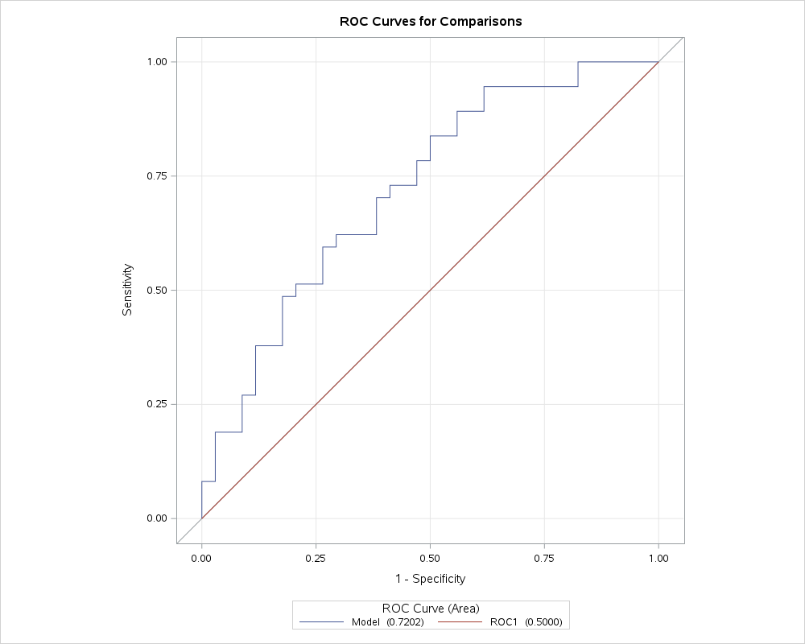

| ROC Association Statistics ROC Model | ROC Association Statistics Mann-Whitney Area | ROC Association Statistics Mann-Whitney Standard Error | ROC Association Statistics Mann-Whitney 95% Wald Confidence Limits | ROC Association Statistics Mann-Whitney 95% Wald Confidence Limits | ROC Association Statistics Somers' D | ROC Association Statistics Gamma | ROC Association Statistics Tau-a |  |  |  |
| --- | --- | --- | --- | --- | --- | --- | --- | --- | --- | --- |
| Model | 0.7202 | 0.0608 | 0.6010 | 0.8394 |  |  |  | 0.4404 | 0.4404 | 0.2229 |
| ROC1 | 0.5000 | 0 | 0.5000 | 0.5000 | 0 | . | 0 |  |  |  |

**log**

```
61                                                         The SAS System                      Friday, December 19, 2025 03:53:00 AM

652        ods listing close;ods html5 (id=saspy_internal) file=_tomods1 options(bitmap_mode='inline') device=svg style=HTMLBlue;
652      ! ods graphics on / outputfmt=png;
653
654        **** Model 2C;
655        ODS EXCLUDE ModelInfo NOBS ResponseProfile ConvergenceStatus ROCcurve;
656        /* Calculate ROC curve and AUC for the model */
657        PROC LOGISTIC DATA = all_results;
658            MODEL progression(EVENT = 'Fast') = tkvht_base lbp_int txti2;
659            OUTPUT OUT = Model2C PREDICTED = Model2Cpred;
660            ROC;
661        RUN;
662
663
664        ods html5 (id=saspy_internal) close;ods listing;
665
62                                                         The SAS System                      Friday, December 19, 2025 03:53:00 AM

666
```

Top of Tabset

**Summary**

The AUC for the model including both baseline kidney volume and MRI image features is 0.72.

Adding baseline kidney volume did not improve the predictive power above and beyond that of using MRI image features alone.

Top of Tabset

## Model Comparison

Table 2. Results of Model Performance Predicting Disease Progression using AUC

| Model | AUC |
| --- | --- |
| Baseline Kidney Volume | 0.52 |
| MRI Image Features | 0.72 |
| Baseline Kidney Volume and MRI | 0.72 |

## Conclusion

The model including MRI images features increased the AUC by 0.20, when compared to the model using baseline kidney volume alone. Including baseline kidney volume did not increase predictive power above that of just using the MRI image features alone.

# Results

#### Predicting Height-Corrected Kidney Volume

| Model | RMSE |
| --- | --- |
| 1A: Baseline Kidney Volume | 7.72 |
| 1B: MRI Image Features | 7.02 |
| 1C Baseline Kidney Volume and MRI | 7.00 |

**lst**

<!DOCTYPE html>

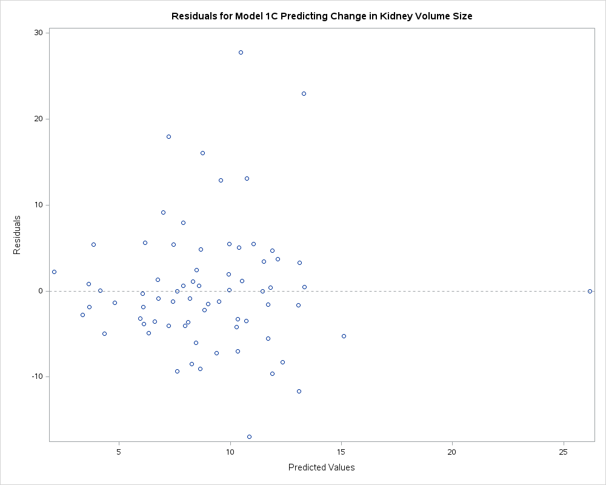

**log**

```
63                                                         The SAS System                      Friday, December 19, 2025 03:53:00 AM

669        ods listing close;ods html5 (id=saspy_internal) file=_tomods1 options(bitmap_mode='inline') device=svg style=HTMLBlue;
669      ! ods graphics on / outputfmt=png;
670
671        * Plot residuals vs. predicted values;
672        PROC SGPLOT DATA = Model1C;
673            SCATTER X=Predicted Y=Residuals;
674            REFLINE 0 / AXIS=y LINEATTRS=(pattern=shortdash);
675            XAXIS LABEL='Predicted Values';
676            YAXIS LABEL='Residuals';
677            TITLE "Residuals for Model 1C Predicting Change in Kidney Volume Size";
678         RUN;
679
680
681        ods html5 (id=saspy_internal) close;ods listing;
682
64                                                         The SAS System                      Friday, December 19, 2025 03:53:00 AM

683
```

To evaluate differences in model performance, RMSE for each model were compared. Model A (Baseline only) had a 0.70 higher RMSE compared to model B (MRI Image features), and a 0.72 higher RMSE compared to model C (Mixed).

Overall, these models did not perform well.

#### Predicting Disease Progression

To evaluate differences in model performance, AUC for each model were compared and ROC curves for each model were plotted. The models using MRI image features alone (AUC = 0.72), or MRI image features and baseline kidney volume (AUC= 0.72), performed better at predicting disease progression speed than the model using baseline kidney volume alone (AUC 0.52).

| Model | AUC |
| --- | --- |
| Baseline Kidney Volume | 0.52 |
| MRI Image Features | 0.72 |
| Baseline Kidney Volume and MRI | 0.72 |

## ROC Curves

Code adapted from [here](https://blogs.sas.com/content/iml/2018/11/14/compare-roc-curves-sas.html)

```sas
*** Final ROC Curves PLOT;
* Merge Data sets;
DATA ROC;
   MERGE Model2A Model2B Model2C;
RUN;


* overlay two or more ROC curves by using variables of predicted values;
PROC LOGISTIC DATA = ROC;
   MODEL progression(EVENT='Fast') = Model2APred Model2BPred Model2CPred / NOFIT;
   ROC 'Model2A' PRED=Model2APred;
   ROC 'Model2B'   PRED=Model2BPred;
   ROC 'Model2C'    PRED=Model2CPred;
   ODS SELECT ROCOverlay;
   /* optional: for a statistical comparison, use ROCCONTRAST stmt and remove the ODS SELECT stmt */
   *roccontrast reference('Expert Model') / estimate e;
RUN;
```

**lst**

<!DOCTYPE html>

Residuals for Model 1C Predicting Change in Kidney Volume Size

The LOGISTIC Procedure

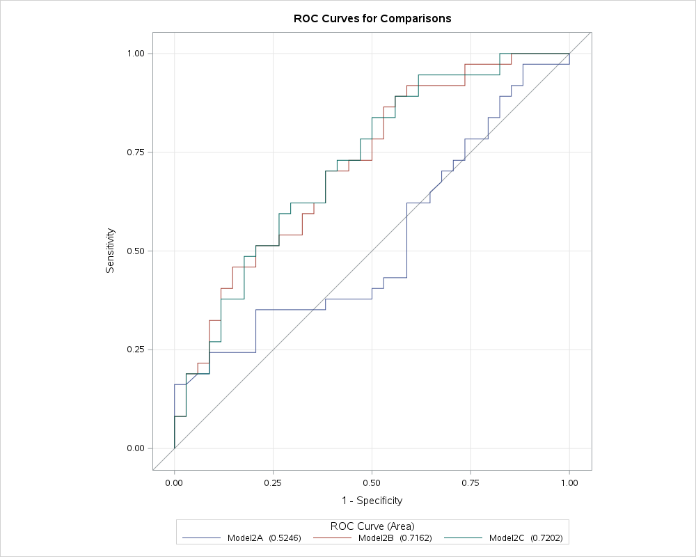

**log**

```
65                                                         The SAS System                      Friday, December 19, 2025 03:53:00 AM

686        ods listing close;ods html5 (id=saspy_internal) file=_tomods1 options(bitmap_mode='inline') device=svg style=HTMLBlue;
686      ! ods graphics on / outputfmt=png;
687
688        *** Final ROC Curves PLOT;
689        * Merge Data sets;
690        DATA ROC;
691           MERGE Model2A Model2B Model2C;
692        RUN;
693
694
695        * overlay two or more ROC curves by using variables of predicted values;
696        PROC LOGISTIC DATA = ROC;
697           MODEL progression(EVENT='Fast') = Model2APred Model2BPred Model2CPred / NOFIT;
698           ROC 'Model2A' PRED=Model2APred;
699           ROC 'Model2B'   PRED=Model2BPred;
700           ROC 'Model2C' PRED=Model2CPred;
701           ODS SELECT ROCOverlay;
702           /* optional: for a statistical comparison, use ROCCONTRAST stmt and remove the ODS SELECT stmt */
703           *roccontrast reference('Expert Model') / estimate e;
704        RUN;
705
706
707        ods html5 (id=saspy_internal) close;ods listing;
708
66                                                         The SAS System                      Friday, December 19, 2025 03:53:00 AM

709
```

# Discussion

In this project we were tasked with identifying whether including MRI image features into a model predicting kidney disease improved model performance above and beyond that of just using baseline kidney volume.

The results of the first series of analyses for task 1 demonstrated that the use of MRI image features *slightly* increased model performance, providing an RMSE that was 0.70 points lower than a model using solely baseline kidney volume.

The results of the second series of analyses for task 2 demonstrated that the use of MRI image features *drastically* improved model performance. The model including MRI image features improved the AUC by 20%.

Moreover, including the baseline kidney measurement volumes did not increase model performance beyond using only MRI image features.